# butte-test

Inigo Peng

2025-07-10

# Database Tables

## Butte

### catch

**- Findings catch:**

- date range is the same
- life stage in edi data has not gone through wrangling

#### Date Range Check

*EDI `visitTime`*

```r
range(catch_butte_edi$visitTime)
```

```
## [1] "2015-11-03 UTC" "2025-04-20 UTC"
```

*DB `date`*

```
## [1] "2015-11-03" "2025-04-20"
```

#### ForkLength

*EDI `forkLength`*

- 9.8 % of values in the `forkLength` column are NA.

```
##    Min. 1st Qu.  Median    Mean 3rd Qu.    Max.    NA's
##    0.00   35.00   37.00   47.08   59.00 1000.00    2229
```

*DB `fork_length`*

- 9.8 % of values in the `fork_length` column are NA.

```
##    Min. 1st Qu.  Median    Mean 3rd Qu.    Max.    NA's
##    0.00   35.00   37.00   47.08   59.00 1000.00    2231
```

*Forklength Exploration Plots*

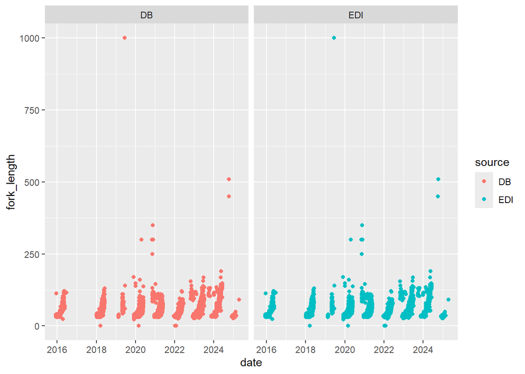

#### Count

*EDI `n`*

- 0 % of values in the `n` column in edi data are NA.

```
##     Min.  1st Qu.   Median     Mean  3rd Qu.     Max.
##     0.00     1.00     1.00    14.14     1.00 33424.00
```

*DB `count`*

- 0 % of values in the `count` column in database data are NA.

```
##     Min.  1st Qu.   Median     Mean  3rd Qu.     Max.
##     0.00     1.00     1.00    14.14     1.00 33424.00
```

Random pick of data entry to compare between db and EDI

- test 1

```
## Rows: 1
## Columns: 17
## $ id               <int> 72543563
## $ catch_raw_id     <chr> "55171"
## $ trap_location_id <int> 8
## $ date             <date> 2024-01-04
## $ count            <dbl> 1
## $ run_id           <int> 5
## $ lifestage_id     <int> 2
## $ adipose_clipped  <lgl> FALSE
## $ dead             <lgl> NA
## $ fork_length      <dbl> 36
## $ weight           <dbl> NA
## $ actual_count     <lgl> TRUE
## $ updated_at       <dttm> 2025-07-10 01:12:38
## $ stream           <chr> "butte creek"
## $ site             <chr> "okie dam"
## $ subsite          <chr> "okie dam fyke trap"
## $ source           <chr> "DB"
```

```
## Rows: 1
## Columns: 20
## $ ProjectDescriptionID <dbl> 11
## $ catchRawID           <dbl> 55171
## $ trapVisitID          <dbl> 2743
## $ commonName           <chr> "Chinook salmon"
## $ releaseID            <dbl> 0
## $ atCaptureRun         <chr> "Spring"
## $ fishOrigin           <chr> "Natural"
## $ lifeStage            <chr> "Fry"
## $ forkLength           <dbl> 36
## $ totalLength          <dbl> NA
## $ n                    <dbl> 1
## $ visitTime            <dttm> 2024-01-04
## $ visitType            <chr> "Continue trapping"
## $ siteName             <chr> "okie dam"
## $ subSiteName          <chr> "okie dam fyke trap"
## $ finalRun             <chr> NA
## $ actualCount          <chr> "Yes"
## $ stream               <chr> "butte creek"
## $ date                 <date> 2024-01-04
## $ source               <chr> "EDI"
```

- test 2

```
## Rows: 1
## Columns: 17
## $ id               <int> 72523953
## $ catch_raw_id     <chr> "518"
## $ trap_location_id <int> 6
## $ date             <date> 2018-01-05
## $ count            <dbl> 0
## $ run_id           <int> 5
## $ lifestage_id     <int> 4
## $ adipose_clipped  <lgl> FALSE
## $ dead             <lgl> NA
## $ fork_length      <dbl> NA
## $ weight           <dbl> NA
## $ actual_count     <lgl> TRUE
## $ updated_at       <dttm> 2025-07-10 01:12:38
## $ stream           <chr> "butte creek"
## $ site             <chr> "okie dam"
## $ subsite          <chr> "okie dam 1"
## $ source           <chr> "DB"
```

```
## Rows: 1
## Columns: 20
## $ ProjectDescriptionID <dbl> 11
## $ catchRawID           <dbl> 518
## $ trapVisitID          <dbl> 73
## $ commonName           <chr> "Chinook salmon"
## $ releaseID            <dbl> 255
## $ atCaptureRun         <chr> "Not recorded"
## $ fishOrigin           <chr> "Natural"
## $ lifeStage            <chr> "Not recorded"
## $ forkLength           <dbl> NA
## $ totalLength          <dbl> NA
## $ n                    <dbl> 0
## $ visitTime            <dttm> 2018-01-05
## $ visitType            <chr> "Continue trapping"
## $ siteName             <chr> "okie dam"
## $ subSiteName          <chr> "okie dam 1"
## $ finalRun             <chr> NA
## $ actualCount          <chr> "Yes"
## $ stream               <chr> "butte creek"
## $ date                 <date> 2018-01-05
## $ source               <chr> "EDI"
```

- test 3

```
## Rows: 1
## Columns: 17
## $ id               <int> 72539231
## $ catch_raw_id     <chr> "51525"
## $ trap_location_id <int> 6
## $ date             <date> 2023-05-24
## $ count            <dbl> 1
## $ run_id           <int> 5
## $ lifestage_id     <int> 6
## $ adipose_clipped  <lgl> FALSE
## $ dead             <lgl> NA
## $ fork_length      <dbl> 85
## $ weight           <dbl> NA
## $ actual_count     <lgl> TRUE
## $ updated_at       <dttm> 2025-07-10 01:12:38
## $ stream           <chr> "butte creek"
## $ site             <chr> "okie dam"
## $ subsite          <chr> "okie dam 1"
## $ source           <chr> "DB"
```

```
## Rows: 1
## Columns: 20
## $ ProjectDescriptionID <dbl> 11
## $ catchRawID           <dbl> 51525
## $ trapVisitID          <dbl> 2462
## $ commonName           <chr> "Chinook salmon"
## $ releaseID            <dbl> 0
## $ atCaptureRun         <chr> "Spring"
## $ fishOrigin           <chr> "Natural"
## $ lifeStage            <chr> "Silvery parr"
## $ forkLength           <dbl> 85
## $ totalLength          <dbl> NA
## $ n                    <dbl> 1
## $ visitTime            <dttm> 2023-05-24
## $ visitType            <chr> "Continue trapping"
## $ siteName             <chr> "okie dam"
## $ subSiteName          <chr> "okie dam 1"
## $ finalRun             <chr> NA
## $ actualCount          <chr> "Yes"
## $ stream               <chr> "butte creek"
## $ date                 <date> 2023-05-24
## $ source               <chr> "EDI"
```

### trap

**- Findings:**

#### Date Range Check

*DB `trap_visit_time_start`*

```
## [1] "2015-11-03 UTC" "2025-04-21 UTC"
```

*EDI `visitTime`*

```r
range(trap_butte_edi$visitTime)
```

```
## [1] "2015-11-03 UTC" "2025-04-21 UTC"
```

#### water_velocity

*DB `water_velocity`*

- 92 % of values in the `water_velocity` column are NA.

```
##    Min. 1st Qu.  Median    Mean 3rd Qu.    Max.    NA's
##   0.100   0.400   0.700   1.728   1.100 183.000    2219
```

*EDI `waterVel`*

- 92 % of values in the `water_velocity` column are NA.

```
##    Min. 1st Qu.  Median    Mean 3rd Qu.    Max.    NA's
##   0.100   0.400   0.700   1.728   1.100 183.000    2219
```

#### fishProcessed

*DB `fish_processed_id`*

- 0 % of values in the `fish_processed_id` column are NA.

```
##
##    1    2    3    4    5
##    1 2116  209    5   81
```

*EDI `fishProcessed`*

- 0 % of values in the `fishProcessed` column are NA.

```
##
##    N/A; not a sampling visit No catch data; fish released
##                           81                            5
##          No fish were caught               Processed fish
##                          209                         2116
```

Random pick of data entry by date to compare between db and EDI

- test 1

```
## Rows: 1
## Columns: 25
## $ id                         <int> 3396057
## $ trap_location_id           <int> 6
## $ trap_visit_id              <chr> "46"
## $ visit_type_id              <int> 2
## $ trap_visit_time_start      <date> 2017-11-10
## $ trap_visit_time_end        <dttm> NA
## $ trap_functioning_id        <int> 2
## $ in_half_cone_configuration <lgl> NA
## $ fish_processed_id          <int> 2
## $ rpm_start                  <dbl> 2
## $ rpm_end                    <dbl> 2
## $ total_revolutions          <dbl> NA
## $ debris_volume              <dbl> NA
## $ debris_level_id            <int> NA
## $ discharge                  <dbl> NA
## $ water_velocity             <dbl> 1.2
## $ water_temp                 <dbl> 9
## $ turbidity                  <dbl> NA
## $ include                    <lgl> TRUE
## $ updated_at                 <dttm> 2025-07-10 01:13:02
## $ updated_by                 <chr> "AdminJPE"
## $ stream                     <chr> "butte creek"
## $ site                       <chr> "okie dam"
## $ subsite                    <chr> "okie dam 1"
## $ source                     <chr> "DB"
```

```
## Rows: 1
## Columns: 19
## $ projectDescriptionID  <dbl> 11
## $ trapVisitID           <dbl> 46
## $ siteName              <chr> "okie dam"
## $ subSiteName           <chr> "okie dam 1"
## $ visitTime             <date> 2017-11-10
## $ visitType             <chr> "Continue trapping"
## $ fishProcessed         <chr> "Processed fish"
## $ trapFunctioning       <chr> "Trap functioning normally"
## $ counterAtEnd          <dbl> NA
## $ rpmRevolutionsAtStart <dbl> 2
## $ rpmRevolutionsAtEnd   <dbl> 2
## $ includeCatch          <chr> "Yes"
## $ discharge             <dbl> NA
## $ waterVel              <dbl> 1.2
## $ waterTemp             <dbl> 9
## $ turbidity             <dbl> NA
## $ stream                <chr> "butte creek"
## $ visit_time            <date> 2017-11-10
## $ source                <chr> "EDI"
```

- test 2

```
## Rows: 1
## Columns: 25
## $ id                         <int> 3397052
## $ trap_location_id           <int> 6
## $ trap_visit_id              <chr> "2144"
## $ visit_type_id              <int> 2
## $ trap_visit_time_start      <dttm> 2022-11-29
## $ trap_visit_time_end        <dttm> NA
## $ trap_functioning_id        <int> 2
## $ in_half_cone_configuration <lgl> NA
## $ fish_processed_id          <int> 2
## $ rpm_start                  <dbl> 1.85
## $ rpm_end                    <dbl> 1.95
## $ total_revolutions          <dbl> 2771
## $ debris_volume              <dbl> NA
## $ debris_level_id            <int> NA
## $ discharge                  <dbl> NA
## $ water_velocity             <dbl> NA
## $ water_temp                 <dbl> 5.4
## $ turbidity                  <dbl> 0.2
## $ include                    <lgl> TRUE
## $ updated_at                 <dttm> 2025-07-10 01:13:02
## $ updated_by                 <chr> "AdminJPE"
## $ stream                     <chr> "butte creek"
## $ site                       <chr> "okie dam"
## $ subsite                    <chr> "okie dam 1"
## $ source                     <chr> "DB"
```

```
## Rows: 1
## Columns: 19
## $ projectDescriptionID  <dbl> 11
## $ trapVisitID           <dbl> 2144
## $ siteName              <chr> "okie dam"
## $ subSiteName           <chr> "okie dam 1"
## $ visitTime             <dttm> 2022-11-29
## $ visitType             <chr> "Continue trapping"
## $ fishProcessed         <chr> "Processed fish"
## $ trapFunctioning       <chr> "Trap functioning normally"
## $ counterAtEnd          <dbl> 2771
## $ rpmRevolutionsAtStart <dbl> 1.85
## $ rpmRevolutionsAtEnd   <dbl> 1.95
## $ includeCatch          <chr> "Yes"
## $ discharge             <dbl> 86
## $ waterVel              <dbl> NA
## $ waterTemp             <dbl> 5.4
## $ turbidity             <dbl> 0.2
## $ stream                <chr> "butte creek"
## $ visit_time            <date> 2022-11-29
## $ source                <chr> "EDI"
```

- test 3

```
## Rows: 1
## Columns: 25
## $ id                         <int> 3397105
## $ trap_location_id           <int> 6
## $ trap_visit_id              <chr> "2327"
## $ visit_type_id              <int> 2
## $ trap_visit_time_start      <dttm> 2023-03-08
## $ trap_visit_time_end        <dttm> NA
## $ trap_functioning_id        <int> 2
## $ in_half_cone_configuration <lgl> NA
## $ fish_processed_id          <int> 2
## $ rpm_start                  <dbl> 3.85
## $ rpm_end                    <dbl> 3.75
## $ total_revolutions          <dbl> 5487
## $ debris_volume              <dbl> NA
## $ debris_level_id            <int> NA
## $ discharge                  <dbl> NA
## $ water_velocity             <dbl> NA
## $ water_temp                 <dbl> 6.9
## $ turbidity                  <dbl> 3.84
## $ include                    <lgl> TRUE
## $ updated_at                 <dttm> 2025-07-10 01:13:02
## $ updated_by                 <chr> "AdminJPE"
## $ stream                     <chr> "butte creek"
## $ site                       <chr> "okie dam"
## $ subsite                    <chr> "okie dam 1"
## $ source                     <chr> "DB"
```

```
## Rows: 1
## Columns: 19
## $ projectDescriptionID  <dbl> 11
## $ trapVisitID           <dbl> 2327
## $ siteName              <chr> "okie dam"
## $ subSiteName           <chr> "okie dam 1"
## $ visitTime             <dttm> 2023-03-08
## $ visitType             <chr> "Continue trapping"
## $ fishProcessed         <chr> "Processed fish"
## $ trapFunctioning       <chr> "Trap functioning normally"
## $ counterAtEnd          <dbl> 5487
## $ rpmRevolutionsAtStart <dbl> 3.85
## $ rpmRevolutionsAtEnd   <dbl> 3.75
## $ includeCatch          <chr> "Yes"
## $ discharge             <dbl> 475
## $ waterVel              <dbl> NA
## $ waterTemp             <dbl> 6.9
## $ turbidity             <dbl> 3.84
## $ stream                <chr> "butte creek"
## $ visit_time            <date> 2023-03-08
## $ source                <chr> "EDI"
```

- test 4

```
## Rows: 1
## Columns: 25
## $ id                         <int> 3397494
## $ trap_location_id           <int> 6
## $ trap_visit_id              <chr> "3151"
## $ visit_type_id              <int> 2
## $ trap_visit_time_start      <dttm> 2024-11-17
## $ trap_visit_time_end        <dttm> NA
## $ trap_functioning_id        <int> 2
## $ in_half_cone_configuration <lgl> NA
## $ fish_processed_id          <int> 3
## $ rpm_start                  <dbl> 3.1
## $ rpm_end                    <dbl> 3.2
## $ total_revolutions          <dbl> 4321
## $ debris_volume              <dbl> NA
## $ debris_level_id            <int> NA
## $ discharge                  <dbl> NA
## $ water_velocity             <dbl> NA
## $ water_temp                 <dbl> 7.6
## $ turbidity                  <dbl> NA
## $ include                    <lgl> TRUE
## $ updated_at                 <dttm> 2025-07-10 01:13:02
## $ updated_by                 <chr> "AdminJPE"
## $ stream                     <chr> "butte creek"
## $ site                       <chr> "okie dam"
## $ subsite                    <chr> "okie dam 1"
## $ source                     <chr> "DB"
```

```
## Rows: 1
## Columns: 19
## $ projectDescriptionID  <dbl> 11
## $ trapVisitID           <dbl> 3151
## $ siteName              <chr> "okie dam"
## $ subSiteName           <chr> "okie dam 1"
## $ visitTime             <dttm> 2024-11-17
## $ visitType             <chr> "Continue trapping"
## $ fishProcessed         <chr> "No fish were caught"
## $ trapFunctioning       <chr> "Trap functioning normally"
## $ counterAtEnd          <dbl> 4321
## $ rpmRevolutionsAtStart <dbl> 3.1
## $ rpmRevolutionsAtEnd   <dbl> 3.2
## $ includeCatch          <chr> "Yes"
## $ discharge             <dbl> 121
## $ waterVel              <dbl> NA
## $ waterTemp             <dbl> 7.6
## $ turbidity             <dbl> NA
## $ stream                <chr> "butte creek"
## $ visit_time            <date> 2024-11-17
## $ source                <chr> "EDI"
```

### release

**- Findings:**

#### Date Range Check

*DB `date_released`*

```
## [1] "2021-01-06 12:30:03 UTC" "2025-01-29 10:15:17 UTC"
```

*EDI `releaseTime`*

```r
range(release_butte_edi$releaseTime)
```

```
## [1] "2021-01-06 12:30:03 UTC" "2025-01-29 10:15:17 UTC"
```

#### Run

*EDI `marked_run`*

- 0 % of values in the `marked_run` column are NA.

```
##
## Spring
##     26
```

*DB `run_id`*

- 0 % of values in the `run_id` column are NA.

```
##
##  2
## 26
```

#### nReleased

*EDI `nReleased`*

- 0 % of values in the `nReleased` column are NA.

```
##    Min. 1st Qu.  Median    Mean 3rd Qu.    Max.
##    52.0   100.0   183.5   189.1   222.8   517.0
```

*DB `number_released`*

- 0 % of values in the `number_released` column are NA.

```
##    Min. 1st Qu.  Median    Mean 3rd Qu.    Max.
##    52.0   100.0   183.5   189.1   222.8   517.0
```

*Exploration Plots*

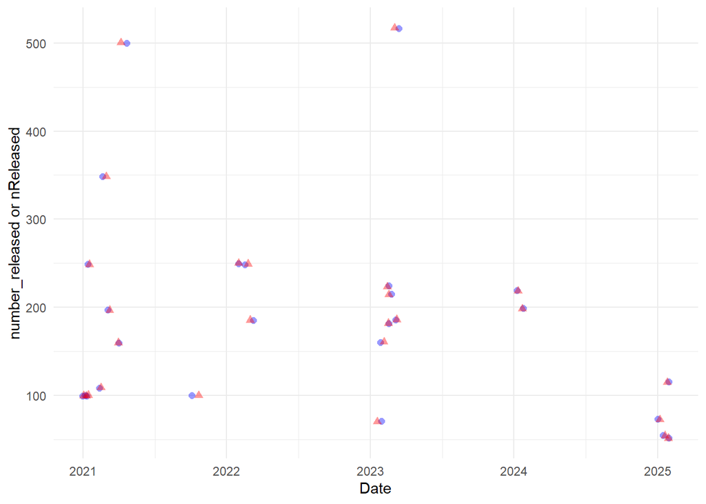

Random pick of data entry by date to compare between db and EDI

- test 1

```
## Rows: 1
## Columns: 15
## $ id                          <int> 129371
## $ trap_location_id            <int> 9
## $ release_id                  <chr> "267"
## $ date_released               <dttm> 2021-04-08 13:00:13
## $ run_id                      <int> 2
## $ median_fork_length_released <dbl> NA
## $ lifestage_id                <int> 11
## $ origin_id                   <int> 1
## $ number_released             <dbl> 160
## $ updated_at                  <dttm> 2025-07-10 01:13:01
## $ updated_by                  <chr> "AdminJPE"
## $ stream                      <chr> "butte creek"
## $ site                        <chr> "okie dam"
## $ subsite                     <chr> NA
## $ source                      <chr> "DB"
```

```
## Rows: 1
## Columns: 20
## $ projectDescriptionID <dbl> 11
## $ releaseID            <dbl> 267
## $ commonName           <chr> "Chinook salmon"
## $ markedRun            <chr> "Spring"
## $ markedLifeStage      <chr> "Juvenile"
## $ markedFishOrigin     <chr> "Natural"
## $ sourceOfFishSite     <chr> "Parrot-Phelan RST"
## $ releaseSite          <chr> "parrott-phelan e-test release site"
## $ releaseSubSite       <chr> NA
## $ nReleased            <dbl> 160
## $ releaseTime          <dttm> 2021-04-08 13:00:13
## $ testDays             <dbl> 7
## $ appliedMarkType      <chr> "Pigment / dye"
## $ appliedMarkColor     <chr> "Brown"
## $ appliedMarkPosition  <chr> "Whole body"
## $ appliedMarkCode      <lgl> NA
## $ includeAnalysis      <chr> "Yes"
## $ stream               <chr> "butte creek"
## $ date_released        <date> 2021-04-08
## $ source               <chr> "EDI"
```

- test 2

```
## Rows: 1
## Columns: 15
## $ id                          <int> 129390
## $ trap_location_id            <int> 9
## $ release_id                  <chr> "284"
## $ date_released               <dttm> 2025-01-29 10:15:17
## $ run_id                      <int> 2
## $ median_fork_length_released <dbl> NA
## $ lifestage_id                <int> 7
## $ origin_id                   <int> 1
## $ number_released             <dbl> 115
## $ updated_at                  <dttm> 2025-07-10 01:13:01
## $ updated_by                  <chr> "AdminJPE"
## $ stream                      <chr> "butte creek"
## $ site                        <chr> "okie dam"
## $ subsite                     <chr> NA
## $ source                      <chr> "DB"
```

```
## Rows: 1
## Columns: 20
## $ projectDescriptionID <dbl> 11
## $ releaseID            <dbl> 284
## $ commonName           <chr> "Chinook salmon"
## $ markedRun            <chr> "Spring"
## $ markedLifeStage      <chr> NA
## $ markedFishOrigin     <chr> "Natural"
## $ sourceOfFishSite     <chr> NA
## $ releaseSite          <chr> "parrott-phelan e-test release site"
## $ releaseSubSite       <chr> NA
## $ nReleased            <dbl> 115
## $ releaseTime          <dttm> 2025-01-29 10:15:17
## $ testDays             <dbl> 7
## $ appliedMarkType      <chr> "Pigment / dye"
## $ appliedMarkColor     <chr> "Brown"
## $ appliedMarkPosition  <chr> "Whole body"
## $ appliedMarkCode      <lgl> NA
## $ includeAnalysis      <chr> "Yes"
## $ stream               <chr> "butte creek"
## $ date_released        <date> 2025-01-29
## $ source               <chr> "EDI"
```

- test 3

```
## Rows: 1
## Columns: 15
## $ id                          <int> 129365
## $ trap_location_id            <int> 9
## $ release_id                  <chr> "256"
## $ date_released               <dttm> 2021-01-06 13:48:05
## $ run_id                      <int> 2
## $ median_fork_length_released <dbl> NA
## $ lifestage_id                <int> 11
## $ origin_id                   <int> 1
## $ number_released             <dbl> 100
## $ updated_at                  <dttm> 2025-07-10 01:13:01
## $ updated_by                  <chr> "AdminJPE"
## $ stream                      <chr> "butte creek"
## $ site                        <chr> "okie dam"
## $ subsite                     <chr> NA
## $ source                      <chr> "DB"
```

```
## Rows: 1
## Columns: 20
## $ projectDescriptionID <dbl> 11
## $ releaseID            <dbl> 256
## $ commonName           <chr> "Chinook salmon"
## $ markedRun            <chr> "Spring"
## $ markedLifeStage      <chr> "Juvenile"
## $ markedFishOrigin     <chr> "Natural"
## $ sourceOfFishSite     <chr> "Parrott-Phelan canal trap box"
## $ releaseSite          <chr> "not applicable"
## $ releaseSubSite       <chr> NA
## $ nReleased            <dbl> 100
## $ releaseTime          <dttm> 2021-01-06 13:48:05
## $ testDays             <dbl> 7
## $ appliedMarkType      <chr> "Pigment / dye"
## $ appliedMarkColor     <chr> "Brown"
## $ appliedMarkPosition  <chr> "Whole body"
## $ appliedMarkCode      <lgl> NA
## $ includeAnalysis      <chr> "Yes"
## $ stream               <chr> "butte creek"
## $ date_released        <date> 2021-01-06
## $ source               <chr> "EDI"
```

### recapture

**- Findings:**

- folk length values all are NA in both DB and EDI

#### Date Range Check

*DB `date`*

```
## [1] "2021-01-07" "2024-01-20"
```

*EDI `date`*

```r
range(recapture_butte_edi$date)
```

```
## [1] "2021-01-07" "2024-01-20"
```

#### Count

*DB `count`*

- 0 % of values in the `count` column are NA.

```
##    Min. 1st Qu.  Median    Mean 3rd Qu.    Max.
##    1.00    2.00    6.00   12.75   13.00  109.00
```

*EDI `n`*

- 0 % of values in the `n` column are NA.

```r
summary(recapture_butte_edi$n)
```

```
##    Min. 1st Qu.  Median    Mean 3rd Qu.    Max.
##    1.00    2.00    6.00   12.75   13.00  109.00
```

#### lifeStage

*EDI `lifeStage`*

- 0 % of values in the `lifeStage` column are NA.

```
##
##          Fry     Juvenile Not recorded
##            1            8           52
```

*DB `lifestage_id`*

- 0 % of values in the `lifestage_id` column are NA.

```
##
##  2  4 11
##  1 52  8
```

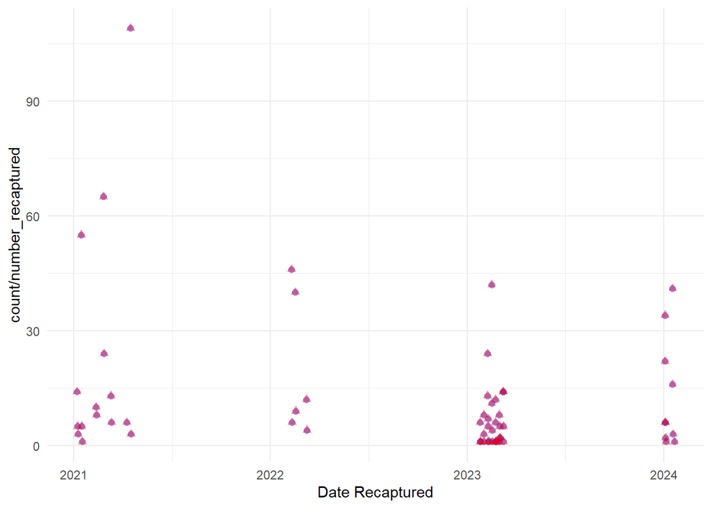

#### forkLength

*EDI `forkLength`*k

- 100 % of values in the `forkLength` column are NA.

*DB `fork_length`*

- 100 % of values in the `fork_length` column are NA.

Random pick of data entry to compare between db and EDI

- test 1

```
## Rows: 1
## Columns: 17
## $ id               <int> 376439
## $ trap_location_id <int> 8
## $ catch_raw_id     <int> 48132
## $ date             <date> 2023-03-01
## $ count            <dbl> 1
## $ run_id           <int> 2
## $ lifestage_id     <int> 4
## $ adipose_clipped  <lgl> FALSE
## $ dead             <lgl> NA
## $ fork_length      <dbl> NA
## $ weight           <dbl> NA
## $ release_id       <chr> "277"
## $ updated_at       <dttm> 2025-07-10 01:13:00
## $ stream           <chr> "butte creek"
## $ site             <chr> "okie dam"
## $ subsite          <chr> "okie dam fyke trap"
## $ source           <chr> "DB"
```

```
## Rows: 1
## Columns: 24
## $ ProjectDescriptionID <dbl> 11
## $ catchRawID           <dbl> 48132
## $ trapVisitID          <dbl> 2314
## $ commonName           <chr> "Chinook salmon"
## $ releaseID            <dbl> 277
## $ atCaptureRun         <chr> "Spring"
## $ finalRun             <chr> NA
## $ fishOrigin           <chr> "Natural"
## $ lifeStage            <chr> "Not recorded"
## $ actualCount          <chr> "Yes"
## $ forkLength           <lgl> NA
## $ totalLength          <lgl> NA
## $ n                    <dbl> 1
## $ visitTime            <dttm> 2023-03-01 08:30:50
## $ visitType            <chr> "Continue trapping"
## $ siteName             <chr> "okie dam"
## $ subSiteName          <chr> "okie dam fyke trap"
## $ markType             <chr> "Pigment / dye"
## $ markColor            <chr> "Brown"
## $ markPosition         <chr> "Whole body"
## $ markCode             <lgl> NA
## $ stream               <chr> "butte creek"
## $ date                 <date> 2023-03-01
## $ source               <chr> "EDI"
```

- test 2

```
## Rows: 1
## Columns: 17
## $ id               <int> 376414
## $ trap_location_id <int> 6
## $ catch_raw_id     <int> 48250
## $ date             <date> 2023-03-03
## $ count            <dbl> 2
## $ run_id           <int> 2
## $ lifestage_id     <int> 4
## $ adipose_clipped  <lgl> FALSE
## $ dead             <lgl> NA
## $ fork_length      <dbl> NA
## $ weight           <dbl> NA
## $ release_id       <chr> "277"
## $ updated_at       <dttm> 2025-07-10 01:13:00
## $ stream           <chr> "butte creek"
## $ site             <chr> "okie dam"
## $ subsite          <chr> "okie dam 1"
## $ source           <chr> "DB"
```

```
## Rows: 1
## Columns: 24
## $ ProjectDescriptionID <dbl> 11
## $ catchRawID           <dbl> 48250
## $ trapVisitID          <dbl> 2317
## $ commonName           <chr> "Chinook salmon"
## $ releaseID            <dbl> 277
## $ atCaptureRun         <chr> "Spring"
## $ finalRun             <chr> NA
## $ fishOrigin           <chr> "Natural"
## $ lifeStage            <chr> "Not recorded"
## $ actualCount          <chr> "Yes"
## $ forkLength           <lgl> NA
## $ totalLength          <lgl> NA
## $ n                    <dbl> 2
## $ visitTime            <dttm> 2023-03-03 09:30:22
## $ visitType            <chr> "Unplanned restart"
## $ siteName             <chr> "okie dam"
## $ subSiteName          <chr> "okie dam 1"
## $ markType             <chr> "Pigment / dye"
## $ markColor            <chr> "Brown"
## $ markPosition         <chr> "Whole body"
## $ markCode             <lgl> NA
## $ stream               <chr> "butte creek"
## $ date                 <date> 2023-03-03
## $ source               <chr> "EDI"
```

- test 3

```
## Rows: 1
## Columns: 17
## $ id               <int> 376408
## $ trap_location_id <int> 6
## $ catch_raw_id     <int> 46604
## $ date             <date> 2023-02-15
## $ count            <dbl> 11
## $ run_id           <int> 2
## $ lifestage_id     <int> 4
## $ adipose_clipped  <lgl> FALSE
## $ dead             <lgl> NA
## $ fork_length      <dbl> NA
## $ weight           <dbl> NA
## $ release_id       <chr> "275"
## $ updated_at       <dttm> 2025-07-10 01:13:00
## $ stream           <chr> "butte creek"
## $ site             <chr> "okie dam"
## $ subsite          <chr> "okie dam 1"
## $ source           <chr> "DB"
```

```
## Rows: 1
## Columns: 24
## $ ProjectDescriptionID <dbl> 11
## $ catchRawID           <dbl> 46604
## $ trapVisitID          <dbl> 2284
## $ commonName           <chr> "Chinook salmon"
## $ releaseID            <dbl> 275
## $ atCaptureRun         <chr> "Spring"
## $ finalRun             <chr> "Spring"
## $ fishOrigin           <chr> "Natural"
## $ lifeStage            <chr> "Not recorded"
## $ actualCount          <chr> "Yes"
## $ forkLength           <lgl> NA
## $ totalLength          <lgl> NA
## $ n                    <dbl> 11
## $ visitTime            <dttm> 2023-02-15 11:00:11
## $ visitType            <chr> "Continue trapping"
## $ siteName             <chr> "okie dam"
## $ subSiteName          <chr> "okie dam 1"
## $ markType             <chr> "Pigment / dye"
## $ markColor            <chr> "Brown"
## $ markPosition         <chr> "Whole body"
## $ markCode             <lgl> NA
## $ stream               <chr> "butte creek"
## $ date                 <date> 2023-02-15
## $ source               <chr> "EDI"
```

- test 4

```
## Rows: 1
## Columns: 17
## $ id               <int> 376404
## $ trap_location_id <int> 6
## $ catch_raw_id     <int> 45421
## $ date             <date> 2023-02-01
## $ count            <dbl> 3
## $ run_id           <int> 2
## $ lifestage_id     <int> 4
## $ adipose_clipped  <lgl> FALSE
## $ dead             <lgl> NA
## $ fork_length      <dbl> NA
## $ weight           <dbl> NA
## $ release_id       <chr> "273"
## $ updated_at       <dttm> 2025-07-10 01:13:00
## $ stream           <chr> "butte creek"
## $ site             <chr> "okie dam"
## $ subsite          <chr> "okie dam 1"
## $ source           <chr> "DB"
```

```
## Rows: 1
## Columns: 24
## $ ProjectDescriptionID <dbl> 11
## $ catchRawID           <dbl> 45421
## $ trapVisitID          <dbl> 2257
## $ commonName           <chr> "Chinook salmon"
## $ releaseID            <dbl> 273
## $ atCaptureRun         <chr> "Spring"
## $ finalRun             <chr> "Not recorded"
## $ fishOrigin           <chr> "Natural"
## $ lifeStage            <chr> "Not recorded"
## $ actualCount          <chr> "Yes"
## $ forkLength           <lgl> NA
## $ totalLength          <lgl> NA
## $ n                    <dbl> 3
## $ visitTime            <dttm> 2023-02-01 12:00:59
## $ visitType            <chr> "Unplanned restart"
## $ siteName             <chr> "okie dam"
## $ subSiteName          <chr> "okie dam 1"
## $ markType             <chr> "Pigment / dye"
## $ markColor            <chr> "Brown"
## $ markPosition         <chr> "Whole body"
## $ markCode             <lgl> NA
## $ stream               <chr> "butte creek"
## $ date                 <date> 2023-02-01
## $ source               <chr> "EDI"
```